[figure not shown]

# Task1 - Exploratory Data Analysis

## Segment the dataset and draw unique insights, including visualisation of the transaction volume and assessing the effect of any outliers.

```python
import numpy as np
import pandas as pd
import datetime
import matplotlib.pyplot as plt
import seaborn as sns
%matplotlib inline
```

```python
# load data
df = pd.read_excel('ANZ synthesised transaction dataset.xlsx')
```

```python
# check dataframe first 5 lines
df.head(3)
```

[output not shown]

```python
# check how many rows and cols
df.shape
```

```
(12043, 23)
```

```python
# extract the column names
df.columns
```

```
Index(['status', 'card_present_flag', 'bpay_biller_code', 'account',
       'currency', 'long_lat', 'txn_description', 'merchant_id',
       'merchant_code', 'first_name', 'balance', 'date', 'gender', 'age',
       'merchant_suburb', 'merchant_state', 'extraction', 'amount',
       'transaction_id', 'country', 'customer_id', 'merchant_long_lat',
       'movement'],
      dtype='object')
```

```python
# check if there are any duplicated data
np.sum(df.duplicated())
```

```
0
```

## exploring data

### Since the columns bpay_biller_code and merchant_code have more than 80% missing data, we remove them.

```python
# check misssing data
np.sum(df.isnull())
```

```
status                   0
card_present_flag     4326
bpay_biller_code     11158
account                  0
currency                 0
long_lat                 0
txn_description          0
merchant_id           4326
merchant_code        11160
first_name               0
balance                  0
date                     0
gender                   0
age                      0
merchant_suburb       4326
merchant_state        4326
extraction               0
amount                   0
transaction_id           0
country                  0
customer_id              0
merchant_long_lat     4326
movement                 0
dtype: int64
```

```python
# drop columns that includes missing data above 80%
df = df.drop(columns = [
    'bpay_biller_code', 'merchant_code'])
```

```python
df.shape
```

```
(12043, 21)
```

```python
df.info()
```

```
<class 'pandas.core.frame.DataFrame'>
RangeIndex: 12043 entries, 0 to 12042
Data columns (total 21 columns):
 #   Column             Non-Null Count  Dtype
---  ------             --------------  -----
 0   status             12043 non-null  object
 1   card_present_flag  7717 non-null   float64
 2   account            12043 non-null  object
 3   currency           12043 non-null  object
 4   long_lat           12043 non-null  object
 5   txn_description    12043 non-null  object
 6   merchant_id        7717 non-null   object
 7   first_name         12043 non-null  object
 8   balance            12043 non-null  float64
 9   date               12043 non-null  datetime64[ns]
 10  gender             12043 non-null  object
 11  age                12043 non-null  int64
 12  merchant_suburb    7717 non-null   object
 13  merchant_state     7717 non-null   object
 14  extraction         12043 non-null  object
 15  amount             12043 non-null  float64
 16  transaction_id     12043 non-null  object
 17  country            12043 non-null  object
 18  customer_id        12043 non-null  object
 19  merchant_long_lat  7717 non-null   object
 20  movement           12043 non-null  object
dtypes: datetime64[ns](1), float64(3), int64(1), object(16)
memory usage: 1.9+ MB
```

```python
# drop rows that include missing data in merchant_id
df.dropna(subset = ['merchant_id'], how = 'any').head(3)
```

|  | status | card_present_flag | account | currency | long_lat | txn_description | merchant_id | first_name | balance | date | ... | age | merchant_suburb | merchant_state | extraction | amount | transaction_id | country | customer_id | merchant_long_lat | movement |
| --- | --- | --- | --- | --- | --- | --- | --- | --- | --- | --- | --- | --- | --- | --- | --- | --- | --- | --- | --- | --- | --- |
| 0 | authorized | 1.0 | ACC-1598451071 | AUD | 153.41 -27.95 | POS | 81c48296-73be-44a7-befa-d053f48ce7cd | Diana | 35.39 | 2018-08-01 | ... | 26 | Ashmore | QLD | 2018-08-01T01:01:15.000+0000 | 16.25 | a623070bfead4541a6b0fff8a09e706c | Australia | CUS-2487424745 | 153.38 -27.99 | debit |
| 1 | authorized | 0.0 | ACC-1598451071 | AUD | 153.41 -27.95 | SALES-POS | 830a451c-316e-4a6a-bf25-e37caedca49e | Diana | 21.20 | 2018-08-01 | ... | 26 | Sydney | NSW | 2018-08-01T01:13:45.000+0000 | 14.19 | 13270a2a902145da9db4c951e04b51b9 | Australia | CUS-2487424745 | 151.21 -33.87 | debit |
| 2 | authorized | 1.0 | ACC-1222300524 | AUD | 151.23 -33.94 | POS | 835c231d-8cdf-4e96-859d-e9d571760cf0 | Michael | 5.71 | 2018-08-01 | ... | 38 | Sydney | NSW | 2018-08-01T01:26:15.000+0000 | 6.42 | feb79e7ecd7048a5a36ec889d1a94270 | Australia | CUS-2142601169 | 151.21 -33.87 | debit |

3 rows × 21 columns

```python
df.describe()
```

|  | card_present_flag | balance | age | amount |
| --- | --- | --- | --- | --- |
| count | 7717.000000 | 12043.000000 | 12043.000000 | 12043.000000 |
| mean | 0.802644 | 14704.195553 | 30.582330 | 187.933588 |
| std | 0.398029 | 31503.722652 | 10.046343 | 592.599934 |
| min | 0.000000 | 0.240000 | 18.000000 | 0.100000 |
| 25% | 1.000000 | 3158.585000 | 22.000000 | 16.000000 |
| 50% | 1.000000 | 6432.010000 | 28.000000 | 29.000000 |
| 75% | 1.000000 | 12465.945000 | 38.000000 | 53.655000 |
| max | 1.000000 | 267128.520000 | 78.000000 | 8835.980000 |

## there are outliers in amount and balance columns, which maximum is 8835.98 and 267128.52 respectively.

### Initially I used the IQR method as outlier detection and replace the outliers with maximum of upper limitation and lower limitation, however, this was not an optimal solution. Then I used the 1st and 99th percentiles method which gives me more control over the data.

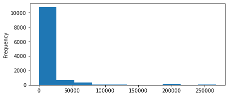

```python
df.balance.plot( kind = 'hist',figsize=(7,3))
```

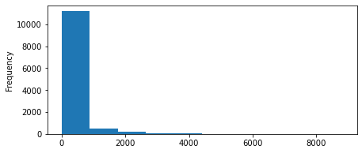

```python
df.amount.plot( kind = 'hist',figsize=(7,3))
```

```python
# Q1 = df.balance.quantile(q = 0.25)
# Q3 = df.balance.quantile(q = 0.75)
# IQR = Q3 - Q1
# any(df.balance > Q3 +1.5 * IQR)
# any(df.balance < Q1 -1.5 * IQR)
# replace_value = df.balance[df.balance < Q3 +1.5 * IQR].max()
# df.loc[df.balance > Q3 +1.5 * IQR, 'balance'] = replace_value
# df.balance.plot(kind = 'hist',figsize=(7,3))
```

```python
# Q1 = df.amount.quantile(q = 0.25)
# Q3 = df.amount.quantile(q = 0.75)
# IQR = Q3 - Q1
# any(df.amount > Q3 +1.5 * IQR)
# replace_value1 = df.amount[df.amount < Q3 +1.5 * IQR].max()
# df.loc[df.amount > Q3 +1.5 * IQR, 'amount'] = replace_value1
# df.amount.plot( kind = 'hist',figsize=(7,3))
```

```python
p99_amount = df['amount'].quantile(0.99)
p1_amount = df['amount'].quantile(0.01)
```

```python
p99_amount
```

```
3195.01
```

```python
df['amount'].max()
```

```
8835.98
```

```python
p99_balance = df['balance'].quantile(0.99)
p1_balance = df['balance'].quantile(0.01)
```

```python
df['balance'].max()
```

```
267128.52
```

```python
df.loc[df['amount'] > p99_amount,'amount'] = p99_amount
df.loc[df['amount'] < p1_amount,'amount'] = p1_amount
```

```python
df['amount'].max()
```

```
3195.01
```

```python
df.loc[df['balance'] > p99_balance,'balance'] = p99_balance
df.loc[df['balance'] < p1_balance,'balance'] = p1_balance
```

```python
df['balance'].max()
```

```
201963.44520000002
```

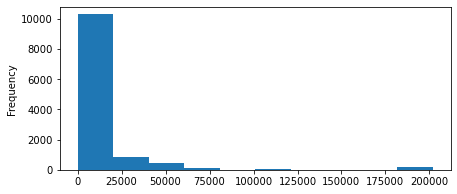

```python
df.balance.plot( kind = 'hist',figsize=(7,3))
```

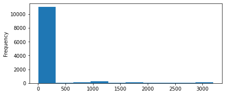

```python
df.amount.plot( kind = 'hist',figsize=(7,3))
```

```python
df['trans_time'] = df['extraction'].apply(lambda x:x.split('T')[1])
```

```python
df['trans_time'] = df['trans_time'].apply(lambda x:x.split(':')[0])
```

```python
df['trans_time'].unique()
```

```
array(['01', '02', '04', '06', '07', '08', '09', '10', '11', '12', '13',
       '14', '15', '16', '17', '18', '19', '20', '21', '22', '23', '00',
       '03', '05'], dtype=object)
```

## Hiding some numbers of account in order to protect customer privacy.

```python
# only keep numbers of account
# df['account'].unique()
df['account'] = df['account'].str[4:]
```

```python
df['account']
```

```
0        1598451071
1        1598451071
2        1222300524
3        1037050564
4        1598451071
            ...
12038    3021093232
12039    1608363396
12040    3827517394
12041    2920611728
12042    1443681913
Name: account, Length: 12043, dtype: object
```

```python
# only show last 4 digits
df['account'] = df['account'].apply(lambda x: x.replace(x[:-4],'****'))
df['account']
```

```
0        ****1071
1        ****1071
2        ****0524
3        ****0564
4        ****1071
           ...
12038    ****3232
12039    ****3396
12040    ****7394
12041    ****1728
12042    ****1913
Name: account, Length: 12043, dtype: object
```

```python
df['date'].value_counts()
```

```
2018-09-28    174
2018-08-17    172
2018-10-05    168
2018-10-17    162
2018-09-14    161
             ...
2018-08-06     99
2018-08-20     97
2018-10-23     96
2018-10-08     95
2018-10-30     89
Name: date, Length: 91, dtype: int64
```

```python
df['trans_day'] = df['date'].dt.day
df['trans_day'].unique()
```

```
array([ 1,  2,  3,  4,  5,  6,  7,  8,  9, 10, 11, 12, 13, 14, 15, 17, 18,
       19, 20, 21, 22, 23, 24, 25, 26, 27, 28, 29, 30, 31, 16])
```